# Section two

## Visual and insights

```python
df_clean.info()
```

```
<class 'pandas.core.frame.DataFrame'>
Int64Index: 2143 entries, 0 to 2142
Data columns (total 20 columns):
 #   Column             Non-Null Count  Dtype
---  ------             --------------  -----
 0   tweet_id           2143 non-null   int64
 1   timestamp          2143 non-null   datetime64[ns, UTC]
 2   source             2143 non-null   object
 3   text               2143 non-null   object
 4   expanded_urls      2094 non-null   object
 5   name               2143 non-null   object
 6   dog_stage          2143 non-null   object
 7   rating_percentage  2143 non-null   int64
 8   likes_count        2143 non-null   int64
 9   jpg_url            1666 non-null   object
 10  img_num            1666 non-null   float64
 11  p1                 1666 non-null   object
 12  p1_conf            1666 non-null   float64
 13  p1_dog             1666 non-null   object
 14  p2                 1666 non-null   object
 15  p2_conf            1666 non-null   float64
 16  p2_dog             1666 non-null   object
 17  p3                 1666 non-null   object
 18  p3_conf            1666 non-null   float64
 19  p3_dog             1666 non-null   object
dtypes: datetime64[ns, UTC](1), float64(4), int64(3), object(12)
memory usage: 351.6+ KB
```

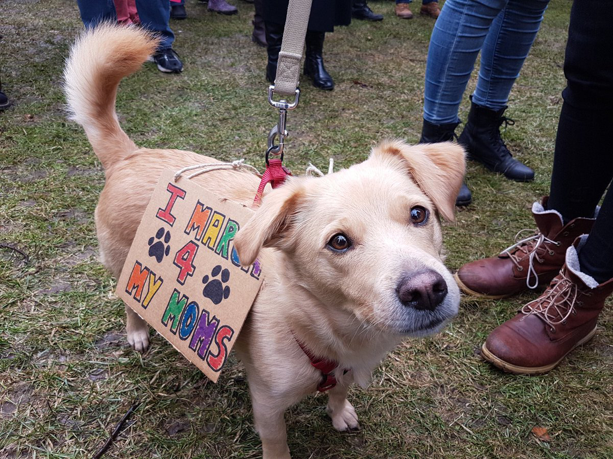

```python
#let us see the dog with the highest likes count
url_high_like=df_clean[df_clean.likes_count==df_clean.likes_count.max()]['jpg_url']
url_high_like=url_high_like.to_string(header=False,index=False) # remove index and headers to use it as a string to download the image
urllib.request.urlretrieve(url_high_like,"doggie.jpg")
display(Image.open("doggie.jpg"))
```

## No doubt that this cute dog deserves to get the most likes ! :) for sure his moms like him

```python
# As mentioned above there are tweets that don't belong to dogs which I filtered them thanks to the image filtration file
# I would like to take a look about the likes count of those tweets
df_clean[df_clean['img_num'].isnull()]['likes_count'].describe()
```

```
count      477.000000
mean      7181.205451
std       9925.897773
min         52.000000
25%       1520.000000
50%       3131.000000
75%       8319.000000
max      74423.000000
Name: likes_count, dtype: float64
```

## I didn't expect having those numbers , I thought just few people will like false dog images , may be some of them were hilarious

## let us show a sample

```python
df_clean[df_clean['img_num'].isnull()]['text'].sample()
```

```
1011    This is old now but it's absolutely heckin fantastic and I can't not share it with you all. 13/10  https://t.co/wJX74TSgzP
Name: text, dtype: object
```

## Let us take a look on dog stages

```python
df_clean[['rating_percentage' ,'likes_count']].describe() # remember that we reomved the outliers
```

|  | rating_percentage | likes_count |
| --- | --- | --- |
| count | 2143.000000 | 2143.000000 |
| mean | 106.168922 | 8799.383108 |
| std | 21.939638 | 12110.482522 |
| min | 0.000000 | 52.000000 |
| 25% | 100.000000 | 1918.500000 |
| 50% | 110.000000 | 4077.000000 |
| 75% | 120.000000 | 11205.000000 |
| max | 140.000000 | 132810.000000 |

```python
# let us plot the ratings distributions
```

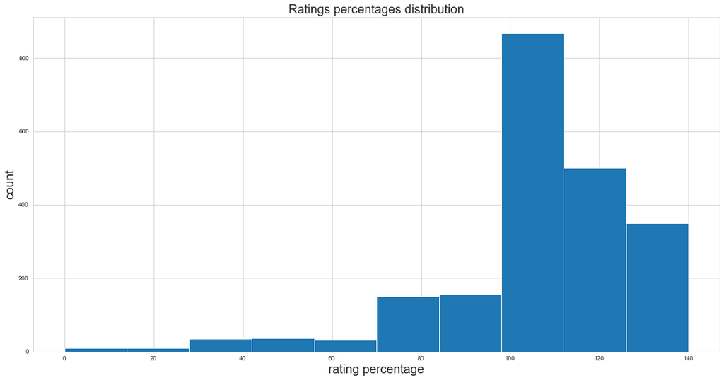

```python
sns.set_style("whitegrid")
df_clean.rating_percentage.plot(kind='hist',figsize=(20,10),fontsize=10)
plt.xlabel("rating percentage",fontsize=20)
plt.ylabel("count",fontsize=20)
plt.title("Ratings percentages distribution",fontsize=20)
```

```python
df_clean.dog_stage.value_counts()
```

```
None             1800
pupper            223
doggo              75
puppo              24
doggo,pupper       10
floofer             9
doggo,floofer       1
doggo,puppo         1
Name: dog_stage, dtype: int64
```

```python
df_clean_dogstage=df_clean.copy()
#elimnate none dog stages
df_clean_dogstage.drop(df_clean_dogstage[df_clean_dogstage.dog_stage.str.match('^None')].index,axis=0,inplace=True)
df_clean_dogstage.dog_stage.value_counts()#Test
```

```
pupper           223
doggo             75
puppo             24
doggo,pupper      10
floofer            9
doggo,floofer      1
doggo,puppo        1
Name: dog_stage, dtype: int64
```

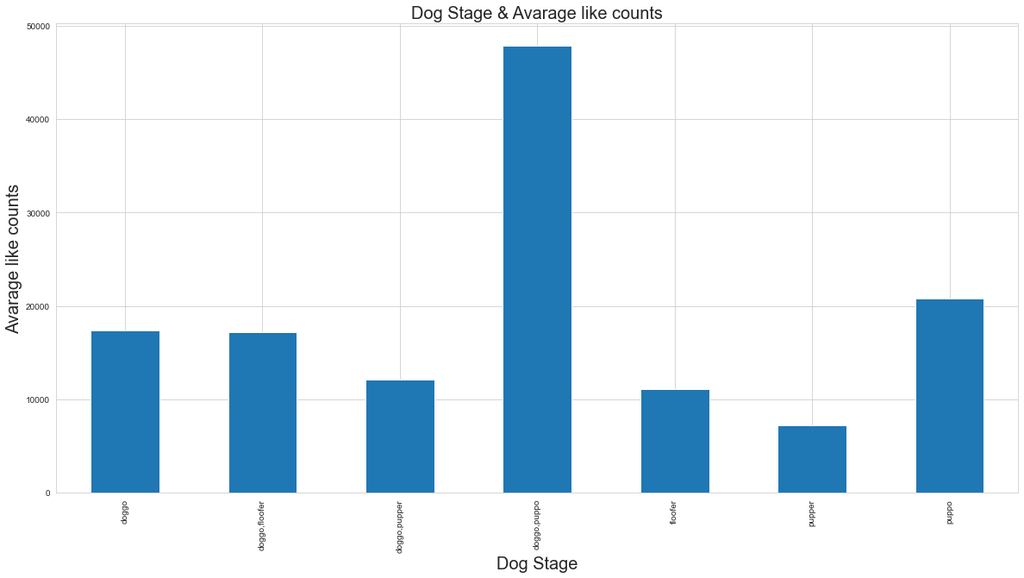

```python
df_clean_dogstage.groupby('dog_stage')['likes_count'].mean().plot(kind='bar',figsize=(20,10))
plt.title('Dog Stage & Avarage like counts', fontsize=20)
plt.xlabel('Dog Stage', fontsize=20)
plt.ylabel('Avarage like counts', fontsize=20)
```

## This shows us something , that the mean is not always the correct way to visualize as the doggo,puppo dog stage has the highest average mean although it was just one tweet.

(Note: there is no a dog stage called doggo,puppo. It's just the algorithm found doggo and puppo in the text)

# Conclusion :

1) Some tweets arenot for real dogs , however some of them got dozens of likes . this is due to the sense of humor of the tweet owner .  
2) Mean isn't always the correct way to visualize data.  
3) High confidence level doesn't mean that it is the correct one . In one tweet it detected the shopping cart as 0.9 Confidence level however there was a Gold retriever dog there . So it is better to use an algorithm that is more tailored to detect dog breeds.  
4) There were high outliers in ratings. I removed those outliers from the analysis because the outliers effect the analysis process badly